# R Notebook

#Load libraries first

```r
library(tidyverse)
library(lubridate)
library(tsibble)
library(tsibbledata)
library(fable)
```

1 Question 1 Load in the nyc_bikes data from the tsibbledata package. Have an initial look at it to see what you’re working with. Create three new columns: one that stores only the year the bike was used, one that stores only the month the bike was used, and one that stores the date. Use the data stored in start_time to create these new columns.

```r
glimpse(nyc_bikes)
```

```
Rows: 4,268
Columns: 12
Key: bike_id [10]
$ bike_id       <fct> 26301, 26301, 26301, 26301, 26301, 26301, 26301, 26301, 2…
$ start_time    <dttm> 2018-02-26 19:11:03, 2018-02-27 07:52:49, 2018-02-27 12:…
$ stop_time     <dttm> 2018-02-26 19:15:40, 2018-02-27 07:58:13, 2018-02-27 12:…
$ start_station <fct> 3186, 3203, 3202, 3638, 3638, 3187, 3638, 3639, 3202, 363…
$ start_lat     <dbl> 40.71959, 40.72760, 40.72722, 40.72429, 40.72429, 40.7211…
$ start_long    <dbl> -74.04312, -74.04425, -74.03376, -74.03548, -74.03548, -7…
$ end_station   <fct> 3203, 3202, 3638, 3638, 3187, 3638, 3639, 3202, 3638, 328…
$ end_lat       <dbl> 40.72760, 40.72722, 40.72429, 40.72429, 40.72112, 40.7242…
$ end_long      <dbl> -74.04425, -74.03376, -74.03548, -74.03548, -74.03805, -7…
$ type          <fct> Subscriber, Subscriber, Subscriber, Subscriber, Subscribe…
$ birth_year    <dbl> 1986, 1979, 1963, 1984, 1980, 1980, 1989, 1962, 1992, 198…
$ gender        <fct> Male, Male, Male, Male, Male, Male, Male, Male, Male, Mal…
```

```r
head(nyc_bikes, 10)
```

| bike_id | start_time | stop_time | start_station | start_lat | start_long | end_station | end_lat | end_long | type | birth_year | gender |
| --- | --- | --- | --- | --- | --- | --- | --- | --- | --- | --- | --- |
| 26301 | 2018-02-26 19:11:03 | 2018-02-26 19:15:40 | 3186 | 40.71959 | -74.04312 | 3203 | 40.72760 | -74.04425 | Subscriber | 1986 | Male |
| 26301 | 2018-02-27 07:52:49 | 2018-02-27 07:58:13 | 3203 | 40.72760 | -74.04425 | 3202 | 40.72722 | -74.03376 | Subscriber | 1979 | Male |
| 26301 | 2018-02-27 12:03:27 | 2018-02-27 12:04:54 | 3202 | 40.72722 | -74.03376 | 3638 | 40.72429 | -74.03548 | Subscriber | 1963 | Male |
| 26301 | 2018-02-27 13:53:51 | 2018-02-27 14:21:04 | 3638 | 40.72429 | -74.03548 | 3638 | 40.72429 | -74.03548 | Subscriber | 1984 | Male |
| 26301 | 2018-02-27 14:30:42 | 2018-02-27 14:33:11 | 3638 | 40.72429 | -74.03548 | 3187 | 40.72112 | -74.03805 | Subscriber | 1980 | Male |
| 26301 | 2018-02-27 16:31:04 | 2018-02-27 16:33:27 | 3187 | 40.72112 | -74.03805 | 3638 | 40.72429 | -74.03548 | Subscriber | 1980 | Male |
| 26301 | 2018-02-27 17:37:12 | 2018-02-27 17:40:49 | 3638 | 40.72429 | -74.03548 | 3639 | 40.71925 | -74.03423 | Subscriber | 1989 | Male |
| 26301 | 2018-02-27 17:49:10 | 2018-02-27 17:55:03 | 3639 | 40.71925 | -74.03423 | 3202 | 40.72722 | -74.03376 | Subscriber | 1962 | Male |
| 26301 | 2018-02-27 18:21:57 | 2018-02-27 18:25:18 | 3202 | 40.72722 | -74.03376 | 3638 | 40.72429 | -74.03548 | Subscriber | 1992 | Male |
| 26301 | 2018-02-27 22:08:55 | 2018-02-27 22:28:42 | 3638 | 40.72429 | -74.03548 | 3281 | 40.74591 | -74.05727 | Subscriber | 1981 | Male |

```r
tail(nyc_bikes, 10)
```

| bike_id | start_time | stop_time | start_station | start_lat | start_long | end_station | end_lat | end_long | type | birth_year | gender |
| --- | --- | --- | --- | --- | --- | --- | --- | --- | --- | --- | --- |
| 33571 | 2018-11-01 12:32:48 | 2018-11-01 12:39:41 | 3195 | 40.73074 | -74.06378 | 3193 | 40.72461 | -74.07841 | Subscriber | 1991 | Female |
| 33571 | 2018-11-01 13:39:11 | 2018-11-01 13:47:34 | 3193 | 40.72461 | -74.07841 | 3195 | 40.73074 | -74.06378 | Subscriber | 1990 | Female |
| 33571 | 2018-11-01 17:39:02 | 2018-11-01 17:45:12 | 3195 | 40.73074 | -74.06378 | 3679 | 40.72210 | -74.07146 | Subscriber | 1985 | Male |
| 33571 | 2018-11-01 18:12:30 | 2018-11-01 18:18:50 | 3679 | 40.72210 | -74.07146 | 3195 | 40.73074 | -74.06378 | Subscriber | 1964 | Male |
| 33571 | 2018-11-01 18:52:10 | 2018-11-01 18:59:39 | 3195 | 40.73074 | -74.06378 | 3210 | 40.74268 | -74.05179 | Subscriber | 1984 | Male |
| 33571 | 2018-11-02 08:50:04 | 2018-11-02 08:55:49 | 3210 | 40.74268 | -74.05179 | 3640 | 40.73367 | -74.06250 | Subscriber | 1984 | Male |
| 33571 | 2018-11-02 17:52:14 | 2018-11-02 18:02:24 | 3640 | 40.73367 | -74.06250 | 3196 | 40.74432 | -74.04399 | Subscriber | 1990 | Male |
| 33571 | 2018-11-04 08:12:56 | 2018-11-04 08:22:25 | 3196 | 40.74432 | -74.04399 | 3269 | 40.72601 | -74.05039 | Subscriber | 1968 | Male |
| 33571 | 2018-11-04 14:27:17 | 2018-11-04 14:35:44 | 3269 | 40.72601 | -74.05039 | 3202 | 40.72722 | -74.03376 | Subscriber | 1990 | Male |
| 33571 | 2018-11-04 18:37:04 | 2018-11-04 18:41:08 | 3202 | 40.72722 | -74.03376 | 3187 | 40.72112 | -74.03805 | Subscriber | 1973 | Male |

```r
nyc_bikes_extra <- nyc_bikes %>%
  mutate(year_used = year(start_time)) %>%
  mutate(month_used = month(start_time, label = TRUE, abbr = FALSE)) %>%
  mutate(date_used = as_date(start_time))
nyc_bikes_extra
```

| bike_id | start_time | stop_time | start_station | start_lat | start_long | end_station | end_lat | end_long | type | birth_year | gender | year_used | month_used | date_used |
| --- | --- | --- | --- | --- | --- | --- | --- | --- | --- | --- | --- | --- | --- | --- |
| 26301 | 2018-02-26 19:11:03 | 2018-02-26 19:15:40 | 3186 | 40.71959 | -74.04312 | 3203 | 40.72760 | -74.04425 | Subscriber | 1986 | Male | 2018 | February | 2018-02-26 |
| 26301 | 2018-02-27 07:52:49 | 2018-02-27 07:58:13 | 3203 | 40.72760 | -74.04425 | 3202 | 40.72722 | -74.03376 | Subscriber | 1979 | Male | 2018 | February | 2018-02-27 |
| 26301 | 2018-02-27 12:03:27 | 2018-02-27 12:04:54 | 3202 | 40.72722 | -74.03376 | 3638 | 40.72429 | -74.03548 | Subscriber | 1963 | Male | 2018 | February | 2018-02-27 |
| 26301 | 2018-02-27 13:53:51 | 2018-02-27 14:21:04 | 3638 | 40.72429 | -74.03548 | 3638 | 40.72429 | -74.03548 | Subscriber | 1984 | Male | 2018 | February | 2018-02-27 |
| 26301 | 2018-02-27 14:30:42 | 2018-02-27 14:33:11 | 3638 | 40.72429 | -74.03548 | 3187 | 40.72112 | -74.03805 | Subscriber | 1980 | Male | 2018 | February | 2018-02-27 |
| 26301 | 2018-02-27 16:31:04 | 2018-02-27 16:33:27 | 3187 | 40.72112 | -74.03805 | 3638 | 40.72429 | -74.03548 | Subscriber | 1980 | Male | 2018 | February | 2018-02-27 |
| 26301 | 2018-02-27 17:37:12 | 2018-02-27 17:40:49 | 3638 | 40.72429 | -74.03548 | 3639 | 40.71925 | -74.03423 | Subscriber | 1989 | Male | 2018 | February | 2018-02-27 |
| 26301 | 2018-02-27 17:49:10 | 2018-02-27 17:55:03 | 3639 | 40.71925 | -74.03423 | 3202 | 40.72722 | -74.03376 | Subscriber | 1962 | Male | 2018 | February | 2018-02-27 |
| 26301 | 2018-02-27 18:21:57 | 2018-02-27 18:25:18 | 3202 | 40.72722 | -74.03376 | 3638 | 40.72429 | -74.03548 | Subscriber | 1992 | Male | 2018 | February | 2018-02-27 |
| 26301 | 2018-02-27 22:08:55 | 2018-02-27 22:28:42 | 3638 | 40.72429 | -74.03548 | 3281 | 40.74591 | -74.05727 | Subscriber | 1981 | Male | 2018 | February | 2018-02-27 |

[output cut: 990 more lines]

2 Question 2 Summarise the number of bike hire counts by month. Make a plot of this data. *Hint: remember that to group time series (tsibble) data, you need to use index_by instead of group_by before your summarise function. What does this plot tell you about the time series? Do you think this downsampled data would be adequate to build a forecast with?

```r
nyc_bikes_monthly <- nyc_bikes_extra %>%
  group_by_key(bike_id) %>%
  index_by(month_used) %>%
  summarise(hire_count = n())
nyc_bikes_monthly
```

| bike_id | month_used | hire_count |
| --- | --- | --- |
| 26301 | February | 12 |
| 26301 | March | 49 |
| 26301 | April | 38 |
| 26301 | May | 41 |
| 26301 | June | 60 |
| 26301 | July | 88 |
| 26301 | August | 106 |
| 26301 | September | 51 |
| 26301 | October | 69 |
| 26301 | November | 10 |

[output cut: 60 more lines]

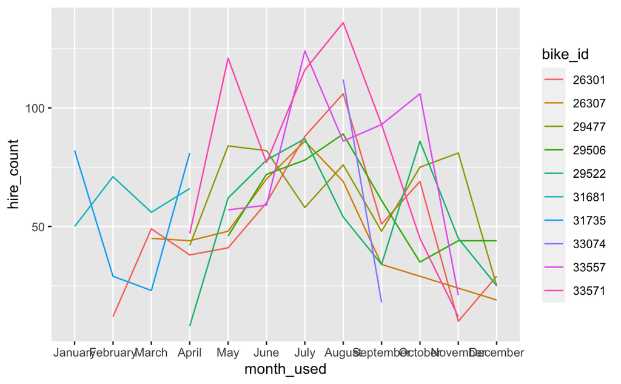

```r
ggplot(data = nyc_bikes_monthly, aes(x = month_used, y = hire_count, group = bike_id)) +
  geom_line(aes(color=bike_id))
```

The above shows us a seasonal trend where bikes are hired more in the summer. As this data is only for 1 year (2018), I would like to see more years before I would be comfortable plotting forecasts.

3 Question 3 Now Summarise the number of bike hire counts by date. Make a plot of this new aggregated data. What does this plot tell you about the time series? Would this data be preferrable for time series forecasting compared to the monthly data?

```r
nyc_bikes_dates <- nyc_bikes_extra %>%
  group_by_key(bike_id) %>%
  index_by(date_used) %>%
  summarise(hire_count = n())
nyc_bikes_dates
```

| bike_id | date_used | hire_count |
| --- | --- | --- |
| 26301 | 2018-02-26 | 1 |
| 26301 | 2018-02-27 | 9 |
| 26301 | 2018-02-28 | 2 |
| 26301 | 2018-03-01 | 1 |
| 26301 | 2018-03-03 | 2 |
| 26301 | 2018-03-04 | 2 |
| 26301 | 2018-03-05 | 4 |
| 26301 | 2018-03-06 | 3 |
| 26301 | 2018-03-08 | 1 |
| 26301 | 2018-03-10 | 2 |

[output cut: 990 more lines]

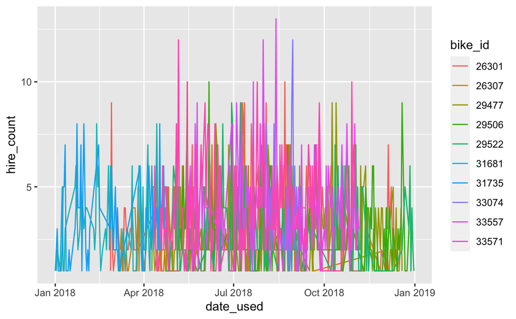

```r
ggplot(data = nyc_bikes_dates, aes(x = date_used, y = hire_count, group = bike_id)) +
  geom_line(aes(color=bike_id))
```

Again, this shows more of a seasonal trend to increased bike hire in the summer months. Also more data again would be ideal (this is only 1 year still) this data would be preferable for forecasting simply because there are more data points. This could perhaps be broken down further into days or weeks to help anlysis.

Question 4

However, the first thing you’ll notice when you try and build a model is that you get an error:

First, create a new tibble which uses the fill_gaps() function to fill in missing values. You haven’t come across this in class, but you should be able to look it up and use it using the help. Think about what value you might want to fill the missing values with. Justify your choice.

```r
fit <- nyc_bikes_dates %>%
  model(
    snaive = SNAIVE(hire_count),
    mean_model = MEAN(hire_count),
    arima = ARIMA(hire_count)
  )
```

```
10 errors (1 unique) encountered for snaive
[10] .data contains implicit gaps in time. You should check your data and convert implicit gaps into explicit missing values using `tsibble::fill_gaps()` if required.
10 errors (1 unique) encountered for arima
[10] .data contains implicit gaps in time. You should check your data and convert implicit gaps into explicit missing values using `tsibble::fill_gaps()` if required.
```

```r
nyc_bikes_dates
```

| bike_id | date_used | hire_count |
| --- | --- | --- |
| 26301 | 2018-02-26 | 1 |
| 26301 | 2018-02-27 | 9 |
| 26301 | 2018-02-28 | 2 |
| 26301 | 2018-03-01 | 1 |
| 26301 | 2018-03-03 | 2 |
| 26301 | 2018-03-04 | 2 |
| 26301 | 2018-03-05 | 4 |
| 26301 | 2018-03-06 | 3 |
| 26301 | 2018-03-08 | 1 |
| 26301 | 2018-03-10 | 2 |

[output cut: 990 more lines]

```r
nyc_bikes_dates_full <- nyc_bikes_dates
fill_gaps(hire_counts = as.integer(median(hire_count)))
```

```
Error in median(hire_count) : object 'hire_count' not found
```

```r
fit <- nyc_bikes_dates_full %>%
  model(
    snaive = SNAIVE(hire_count),
    mean_model = MEAN(hire_count),
    arima = ARIMA(hire_count)
  )
fit
```

[output not shown]

Question 5 Now we have our model fit, build a forecast to predict bike use over the next four months. Plot your models alongside your data. Hint: forecast parameter would be roughly 120 (30 days x 4 months)

```r
forecast_bikes <- fit %>%
  fabletools::forecast(h = "1 year") #forecast for next 12 months
forecast_bikes
```

[output not shown]

```r
forecast_bikes %>%
  autoplot(nyc_bikes_dates_full, level = NULL) +
  ggtitle("Forecasts for bike sales") +
  xlab("Month") +
  guides(colour = guide_legend(title = "Forecast"))
```

[output not shown]